# Tema 4 - Variables Aleatorias continuas multidimensionales

## Variables aleatorias bidimensionales continuas

## Variables aleatorias bidimensionales continuas Introducción

Definición de variable aleatoria bidimensional continua.

Recordemos que una v.a. bidimensional **continua** cuando su conjunto de valores en \(\mathbb{R}^2\), \((X,Y)(\Omega)\) es un producto de intervalos.

Definición función de distribución conjunta

La función de distribución acumulada conjunto o simplemente distribución conjunta se define como

\[F_{XY}(x,y)=P(X\leq x,Y\leq y).\]

## Función de distribución acumulada, función de densidad

Definición función de densidad conjunta

Sea \(f_{XY}: \mathbb{R}\times \mathbb{R}\mapsto [0,+\infty)\) diremos que es una densidad bidimensional del vector aleatorio bidimensional \((X,Y)\) si

\[F_{XY}(x,y)=\int_{-\infty}^{x}\int_{-\infty}^{y} f_{XY}(t_x,t_y) dt_xdt_y.\]

Llamaremos dominio de la variable conjunta a \[D_{XY}=\{(x,y)\in \mathbb{R}^2 | f_{XY}(x,y)>0\}.\]

Es decir es el conjunto de valores posibles que toma la v.a. \((X,Y)\).

## Gráfica de una función de densidad

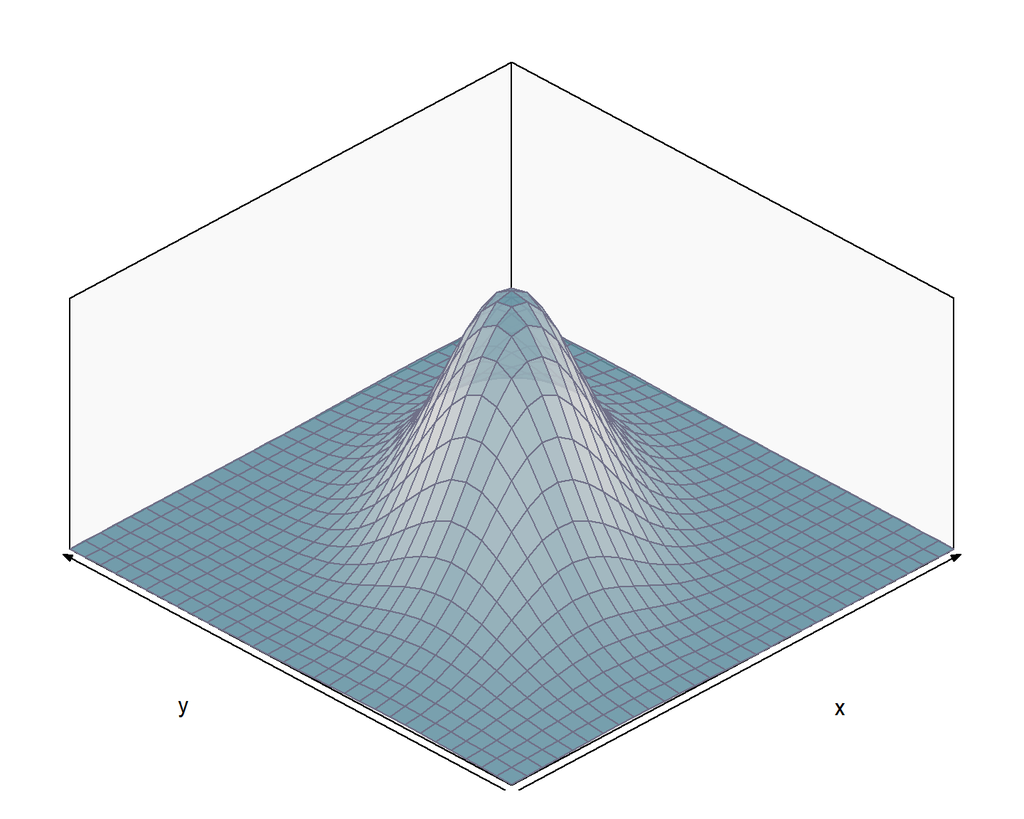

## Propiedades de la función de densidad conjunta

Sea \((X,Y)\) una **variable aleatoria bidimensional continua** con dominio \(D_{XY}\subset \mathbb{R}^2\).

Su **función de densidad conjunta** verifica las siguientes propiedades:

- \[\int_{-\infty}^{+\infty}\int_{-\infty}^{+\infty} f_{XY}(x,y)\quad dx dy=1.\]
- Sea \(B\) un subconjunto cualquiera del dominio \(D_{XY}\). El valor de la probabilidad \(P((X,Y)\in B)\) se puede calcular de la forma siguiente: \[ P((X,Y)\in B) ={\int\int}_B f_{XY}(x,y)\quad dx dy. \]

Es decir, la probabilidad de que la variable bidimensional tome valores en \(B\) es igual al volumen que genera la densidad conjunta sobre el recinto \(B\).

## Distribuciones marginales

## Variables aleatorias marginales y su distribución

Consideremos una variable aleatoria **bidimensional continua \((X,Y)\)** con **función de densidad conjunta** \(f_{XY}(x,y)\) y con dominio \(D_{XY}\).

La de la **función de densidad conjunta** contiene suficiente información para obtener las **funciones de densidad** de las variables \(X\) e \(Y\).

Dichas variables \(X\) e \(Y\) se denominan **variables marginales** y sus correspondientes **funciones de densidad**, **funciones de densidad marginales** \(f_X\) de la variable \(X\) y \(f_Y\) de la variable \(Y\).

Veamos cómo obtener \(f_X\) y \(f_Y\) a partir de la tabla \(f_{XY}\).

## Funciones de probabilidad marginales

Proposición. Cálculo de las funciones de densidad marginales.

Sea \((X,Y)\) una variable aleatoria **bidimensional continua** con **función de densidad conjunta** \(f_{XY}(x,y)\), con \((x,y)\in D_{XY}\).

Las **funciones de densidad marginales** \(f_X(x)\) y \(f_Y(y)\) se calculan usando las expresiones siguientes:

- \(f_X(x)= \int_{-\infty}^{+\infty} f_{XY}(x,y)\quad dy.\)
- \(f_Y(y)= \int_{-\infty}^{+\infty} f_{XY}(x,y)\quad dx.\)

## Independencia de variables aleatorias continuas

Recordemos que dos sucesos \(A\) y \(B\) son independientes si

\[P(A\cap B)=P(A)\cdot P(B).\]

¿Cómo trasladar dicho concepto al caso de variables aleatorias continuas?

Así que al menos todos los sucesos de la forma \(P\left(X\leq x ,\ Y\leq y\right)\) deberán ser independientes.

Esto implicará que cualesquiera dos sucesos de cada variables con independientes.

## Independencia de variables aleatorias continuas

Condiciones para independencia de variables aleatorias bidimensionales continuas

Dada \((X,Y)\) una **variable aleatoria bidimensional continua** con **función de densidad** \(f_{XY}\) y **funciones de probabilidad marginales** \(f_X\) y \(f_Y\).

Diremos que \(X\) e \(Y\) son independientes si se cumple al menos una de las siguientes condiciones:

- \(f_{XY}(x,y)=f_X(x)\cdot f_Y(y)\) para todo \((x,y)\in D_{XY}\)
- \(F_{XY}(x,y)=F_X(x)\cdot F_Y(y)\) para todo \((x,y)\in D_{XY}\)

## Esperanza y varianza de las distribuciones marginales

- \(E(X)=\int_{-\infty}^{+\infty} x\cdot f_X(x)\quad dx.\)
- \(E(Y)=\int_{-\infty}^{+\infty} y\cdot f_Y(y)\quad dy.\)
- \(\sigma_X^2=Var(X)=E(X-E(X))=E(X)-E(X)^2.\)
- \(\sigma_Y^2=Var(Y)=E(Y-E(Y))=E(Y)-E(Y)^2.\)

## Distibuciones condicionales

- Dado un valor fijo \(y\in D_Y\) definimos la distribución condicional de la v.a. \(X\) condicionada a que \(Y=y\) como

\[f_{X|Y=y}(x)=\frac{f_{XY}(x,y)}{f_Y(y)},\mbox{ para todo } x\in D_X.\]

- Dado un valor fijo \(y\in D_Y\) definimos la distribución condicional de la v.a. \(Y\) condicionada a que \(X=x\) como

\[f_{Y|X=x}(y)=\frac{f_{XY}(x,y)}{f_X(x)},\mbox{ para todo } Y\in D_Y.\]

## Distibuciones condicionales e independencia

Propiedad

Si las variables \(X\) e \(Y\) son independientes se cumple que

- \(f_{X|Y=y}(x)=f_X(x)\)
- \(f_{Y|X=x}(y)=f_Y(y)\)

## Esperanzas condicionales

\[E(X|Y=y)=\int_{-\infty}^{+\infty} x\cdot f_{X|Y=y}(x) \quad dx.\]

\[E(Y|X=x)=\int_{-\infty}^{+\infty} y\cdot f_{Y|X=x}(y) \quad dy.\]

Propiedad

Si las variables \(X\) e \(Y\) son independientes se cumple que

1. \(E(X|Y=y)=E(X)\)
2. \(E(Y|X=x)=E(Y)\)

## Esperanzas de funciones de v.a. continuas bidimensionales. Covarianza y correlación

## Esperanzas de funciones de v.a. continuas bidimensionales

Definición:

Sea \((X,Y)\) una variable aleatoria bidimensional continua y \(g(X,Y): \mathbb{R}^2\mapsto \mathbb{R}\) una función de esa variable bidimensional entonces

\[E(g(X,Y))=\int_{-\infty}^{+\infty}\int_{-\infty}^{+\infty} g(x,y) \cdot f_{XY}(x,y) \quad dx dy.\]

## Esperanzas de funciones de v.a. continuas bidimensionales

Propiedad: En particular:

\[ E(X+Y)=\int_{-\infty}^{+\infty}\int_{-\infty}^{+\infty} (x+y)\cdot f_{XY}(x,y) \quad dx dy=\mu_X+\mu_Y. \]

\[ \begin{eqnarray*} Var(X+Y)&&\\ &=&E\left(\left(X+Y-E(X+Y)\right)^2\right)\\ &=& \int_{-\infty}^{+\infty}\int_{-\infty}^{+\infty}(x+y-(\mu_X+\mu_Y))^2\cdot f_{XY}(x,y) \quad dx dy. \end{eqnarray*} \]

## Esperanzas de funciones de v.a. continuas bidimensionales

Propiedad: Sea \((X,Y)\) una variable aleatoria bidimensional entonces se cumple que:

- \(E(X+Y)=E(X)+E(Y)=\mu_X+ \mu_Y\).
- Si \(X\) e \(Y\) son independientes entonces \(E(X\cdot Y)=E(X)\cdot E(Y)=\mu_X\cdot \mu_Y\).
- Si \(X\) e \(Y\) son independientes entonces \(Var(X+Y)=Var(X)+ Var(Y)=\sigma_X^2+ \sigma_y^2\).

## Covarianza y correlación

## Medida de la variación conjunta: covarianza

Se denomina **covarianza** entre las variables \(X\) e \(Y\): \[ \sigma_{XY}=Cov(X,Y)=E((X-\mu_X)(Y-\mu_Y)). \] La covarianza puede calcularse también con: \[ Cov(X,Y)=E(X\cdot Y)-E(X)\cdot E(Y)=E(X\cdot Y)-\mu_X\cdot \mu_Y, \]

Propiedad. Si las variables \(X\) e \(Y\) son **independientes**, entonces \(Cov(X,Y)=0\).

Es una consecuencia de que si \(X\) e \(Y\) son independientes entonces que vimos que \(E(X\cdot Y)=E(X)\cdot E(Y) =\mu_X\cdot \mu_Y\).

## Covarianza entre las variables

La **covarianza** es una medida de lo relacionadas están las variables \(X\) e \(Y\):

- Si cuando \(X\geq \mu_X\), también ocurre que \(Y\geq \mu_Y\) o viceversa, cuando \(X\leq \mu_X\), también ocurre que \(Y\leq \mu_Y\), el valor \((X-\mu_X)(Y-\mu_Y)\) será positivo y la **covarianza** será positiva.
- Si por el contrario, cuando \(X\geq \mu_X\), también ocurre que \(Y\leq \mu_Y\) o viceversa, cuando \(X\leq \mu_X\), también ocurre que \(Y\geq \mu_Y\), el valor \((X-\mu_X)(Y-\mu_Y)\) será negativo y la **covarianza** será negativa.
- En cambio, si a veces ocurre una cosa y a veces ocurre otra, la **covarianza** va cambiando de signo y puede tener un valor cercano a 0.

## Propiedades de la covarianza

- Sea \((X,Y)\) una variable aleatoria bidimensional. Entonces la **varianza de la suma/resta** se calcula usando la expresión siguiente: \[ Var(X\pm Y)=Var(X)+Var(Y)\pm 2\cdot Cov(X,Y). \]
- Sea \((X,Y)\) una variable aleatoria bidimensional donde las variables \(X\) e \(Y\) son **independientes**. Entonces: \[ Var(X+Y)=Var(X)+Var(Y). \]

## Coeficiente de correlación entre las variables

Definición del coeficiente de correlación. Sea \((X,Y)\) una variable aleatoria bidimensional. Se define el **coeficiente de correlación** entre las variables \(X\) e \(Y\) como: \[ \rho_{XY}=\frac{Cov(X,Y)}{\sqrt{Var(X)}\cdot\sqrt{Var(Y)}}=\frac{E(X\cdot Y)-\mu_X\cdot \mu_Y}{\sqrt{E\left(X^2\right)-\mu_X^2}\cdot \sqrt{E\left(Y^2\right)-\mu_Y^2}}. \]

## Coeficiente de correlación entre las variables

Observación: Si las variables \(X\) e \(Y\) son **independientes**, su **coeficiente de correlación** \(\rho_{XY}=0\) es nulo ya que su **covarianza** lo es.

Notemos también que la **correlación** no tiene unidades y es invariante a cambios de escala.

Además, la **covarianza** de las **variables tipificadas** \(\frac{X-\mu_X}{\sigma_X}\) y \(\frac{Y-\mu_Y}{\sigma_Y}\) coincide con la **correlación** de \(X\) e \(Y\).

El **coeficiente de correlación** es un valor normalizado ya que siempre está entre -1 y 1: \(-1\leq\rho_{XY}\leq 1\).

## Coeficiente de correlación entre las variables

Observación. Si las variables \(X\) e \(Y\) tiene dependencia lineal, por ejemplo si \(Y=a\cdot X+b\) para algunas constantes \(a,b\in\mathbb{R}\), entonces su **coeficiente de correlación** \(\rho_{XY}=\pm 1\), es decir toma el valor \(1\) si la pendiente \(a>0\) y \(-1\) si \(a<0\).

De forma similar:

- si \(Cor(X,Y)=+1\) \(X\) e \(Y\) tienen relación lineal con pendiente positiva.
- si \(Cor(X,Y)=-1\) \(X\) e \(Y\) tienen relación lineal con pendiente negativa.

## Matriz de varianzas-covarianzas y matriz de correlaciones

Sea \((X,Y)\) una variable bidimensional Notemos que

- \(Cov(X,X)=\sigma_{X X}=\sigma_{X}^2.\)
- \(Cov(Y,Y)=\sigma_{Y Y}=\sigma_{Y}^2.\)
- \(\sigma_{X Y}= Cov(X,Y)=Cov(Y,X)= \sigma_{Y X}.\)

Se denomina matriz de varianzas-covarianzas y se suele denotar como \(\Sigma\) a

\[ \Sigma= \left( \begin{matrix} Cov(X,X) & Cov(X,Y)\\ Cov(Y,X) & Cov(Y,Y) \end{matrix} \right)= \pmatrix{\sigma_{XX} & \sigma_{XY}\\ \sigma_{YX} & \sigma_{YY}}= \pmatrix{\sigma_{X}^2 & \sigma_{XY}\\ \sigma_{Y X} & \sigma_{Y}^2} \]

## Matriz de varianzas-covarianzas y matriz de correlaciones

Sea \((X,Y)\) una variable bidimensional Notemos que

- \(Cor(X,X)=\rho_{X X}=1.\)
- \(Cor(Y,Y)=\rho_{Y Y}=1.\)
- \(\rho_{X Y}= Cor(X,Y)=Cor(Y,X)= \rho_{Y X}.\)

## Matriz de varianzas-covarianzas y matriz de correlaciones

Se denomina matriz de correlaciones a

\[ R= \left( \begin{matrix}Cor(X,X) & Cor(X,Y)\\ Cor(Y,X) & Cor(Y,Y) \end{matrix} \right) = \left( \begin{matrix} 1 & \rho_{XY}\\ \rho_{Y X} & 1 \end{matrix} \right)= \left( \begin{matrix} 1 & \rho_{XY}\\ \rho_{X Y} & 1 \end{matrix} \right). \]

## La distribución normal bivariante

## Definición de distribción normal bivariante

Sea \((X,Y)\) una variable continua bidimensional con \(E(X)=\mu_X\), \(E(Y)=\mu_X\)

\(\sigma^2_X=Var(X)\), \(\sigma^2_Y=Var(Y)\), \(\sigma_{XY}=Cov(X,Y)\).

Y si denotamos por

\[ \mathbf{\mu}=\left(\begin{array}{c}\mu_X \\ \mu_Y\end{array}\right) \]

y por

\[ \Sigma=\left(\begin{matrix} \sigma_{X}^2 & \sigma_{XY}\\ \sigma_{XY} & \sigma_{Y}^2 \end{matrix}\right). \]

## Definición de distribción normal bivariante

Diremos que el vector \(\left(\begin{array}{c} X \\ Y\end{array}\right)\) sigue una ley **normal o gaussiana bidimensional** \(N(\mathbb{b},\sigma)\) si su densidad es

\[ f_{XY}=\frac{1}{\sqrt{(2\pi)^2\cdot \mathrm{det}(\Sigma)}} \cdot e^{-\frac{1}{2} ((x,y)-\mathbf{\mu})^t\cdot \Sigma^{-1}\cdot ((x,y)-\mathbf{\mu})^t}. \]

## Gráfica de la distribución gaussiana \((X,Y)\).

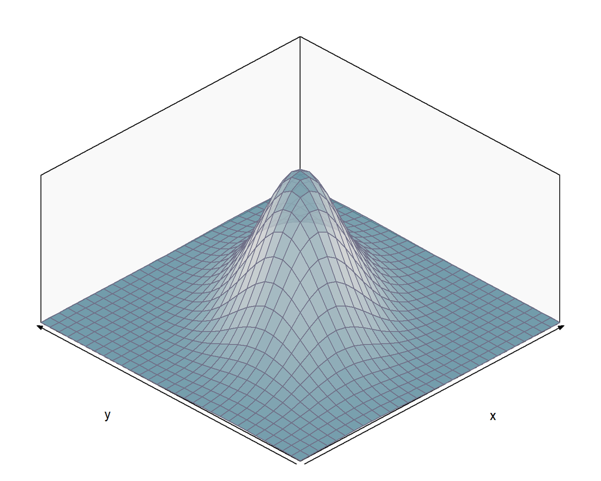

## Distribuciones multidimensionales

## Conceptos básicos. Función de probabilidad y de distribución.

Consideremos un vector compuesto de \(n\) variables aleatorias continuas \((X_1,X_2,\ldots,X_n)\)

Su **función de densidad de probabilidad** es una función \(f_{X_1,X_2,\ldots, X_n}:\mathbb{R}^n\mapsto [0,+\infty)\) tal que

\[ \begin{eqnarray*} F_{X_1,X_2,\ldots, X_n}(x_1,x_2,&\ldots&,x_n)=P(X_1\leq x_1,X_2\leq x_2,\ldots, X_n\leq x_n)\\&=&\int_{-\infty}^{x1}\int_{-\infty}^{x2}\cdots \int_{-\infty}^{xn} f(t_1,t_3,\ldots,t_n)\quad dt_1 dt_2\cdots dt_n. \end{eqnarray*} \]

## Independencia

Definición independencia

Diremos que la variables continuas \(X_1,X_2,\ldots, X_n\) son **INDEPENDIENTES** cuando \[f_{X_1,X_2,\ldots, X_n}(x_1,x_2,\ldots,x_n) =f_{X_1}(x_1)\cdot f_{X_2}(x_2)\cdot \ldots \cdot f_{X_n}(x_n).\]

Propiedad

Las variables \(X_1,X_2,\ldots, X_n\) son **INDEPENDIENTES** si y solo si \[F_{X_1,X_2,\ldots, X_n}(x_1,x_2,\ldots,x_n)=F_{X_1}(x_1)\cdot F_{X_2}(x_2)\cdot \ldots \cdot F_{X_n}(x_n).\]

## Conceptos básicos

Vector de medias

Si denotamos \(E(X_i)=\mu_i\) para \(i=1,2,\ldots,n\) el **vector de medias** es \[E(X_1,X_2,\ldots,X_n)=(E(X_1),E(X_2),\ldots,E(X_n))=(\mu_1,\mu_2,\ldots,\mu_n).\]

Covarianza y varianzas

Si denotamos \(\sigma_{ij}=Cov(X_i,X_j)\) para todo \(i,j\) en \(1,2,\ldots n\) entonces tenemos que

- \(\sigma_{ii}=Cov(X_i,X_i )=\sigma_{ii}=\sigma_{i} ^2.\)
- \(\sigma_{ij}=Cov(X_i,X_j )=Cov(X_j,X_i)=\sigma_{ji}.\)

## Conceptos básicos

Si denotamos \(\rho_{ij}=Cor(X_i,X_j)\) para todo \(i,j\) en \(1,2,\ldots n\) entonces tenemos que

- \(\rho_{ii}=Cor(X_i,X_i)=1.\)
- \(\rho_{ij}=Cor(X_i,X_j)=Cor(X_j,X_i)=\rho_{ji}.\)

## Matrices de varianzas-covarianzas y de correlaciones

\[\Sigma= \left(\begin{matrix} \sigma_{1}^2 & \sigma_{12} & \ldots & \sigma_{1n}\\ \sigma_{21} & \sigma_{2}^2 & \ldots & \sigma_{2n}\\ \vdots & \vdots & \ddots& \vdots\\ \sigma_{n1} & \sigma_{n2} & \ldots & \sigma_{n}^2 \end{matrix}\right) , \qquad R=\left(\begin{matrix} 1 & \rho_{12} & \ldots & \rho_{1n}\\ \rho_{21} & 1 & \ldots & \rho_{2n}\\ \vdots & \vdots & \ddots& \vdots\\ \rho_{n1} & \rho_{n2} & \ldots & 1 \end{matrix}\right). \]